# Dates and Times make me go R

Carl Frederick

10/16/2020

# Dates and Times in R

list of types:

- character - safest for import/export
- numeric - necessary for calculations
  - Date
  - POSIX - “portable operating system interface for unix (and other OS’s)”
    - POSIXct - you should probably use this
    - POSIXlt - list components
  - {`chron`} - an longstanding R package for easy handling of dates and times (and times without dates).

# Formatting Dates for nice output

For a full list see `?strptime`

Dates

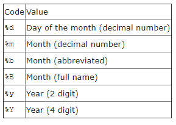

Datetimes

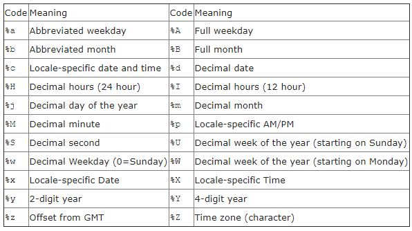

# Working with dates: base R

You can do many simple operations on dates with the usual functions:

- addition, subtraction
- mean, min, max,
- round, ceiling, floor

You can also generate sequences of dates:

```r
seq(as.Date('2000-6-1'),to=as.Date('2000-8-1'),by='2 weeks')
```

```
## [1] "2000-06-01" "2000-06-15" "2000-06-29" "2000-07-13" "2000-07-27"
```

# Working with dates: {`chron`}

Either the [chron manual](https://cran.rstudio.com/web/packages/chron/chron.pdf) or [this link to a page at UC-Berkeley](https://statistics.berkeley.edu/computing/r-dates-times)

# Working with dates: {`lubridate`}

See [“Dates and Times” chapter in R for Data Science](https://r4ds.had.co.nz/dates-and-times.html)

There are a couple of things that lubridate makes super easy.

1. Converting dates from character strings in multiple formats.
2. Operating with time periods.

# Origin

```r
library(tidyverse)
library(chron)
library(lubridate)
```

Date: days since 1970-01-01

```r
as.numeric(as.Date("1970-01-01"))
```

```
## [1] 0
```

POSIX: seconds since 1970-01-01 00:00:00 *UTC*

```r
#Compare
as.numeric(as.POSIXct("1970-01-01 00:00:00"))
```

```
## [1] 21600
```

```r
as.numeric(as.POSIXct("1970-01-01 00:00:00", tz = "America/Chicago"))
```

```
## [1] 21600
```

```r
as.numeric(as.POSIXct("1970-01-01 00:00:00", tz = "UTC"))
```

```
## [1] 0
```

# Getting dates into and out of excel

Unless they are stored as characters, we often need to convert the dates from an excel import using the `origin` argument.

So, what is excel’s origin? After googling …. it depends! probably on your version/language of Excel and your operating system[^1]

Here is how DPI’s version of Excel on Windows 10 works:

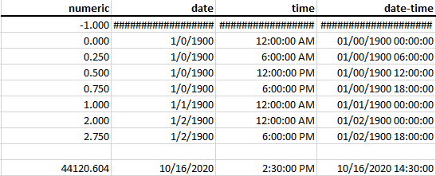

Fun fact: Excel wrongly assumes that 1900 was a leap year so the numbers from March 1, 1900 should all be one less than they are.

# Equivalent Table for R

Note: Origin is taken to be 1970-01-01 00:00:00 UTC

```r
tibble(numeric_days = c(-1, 0, .25, .5, .75, 1, 2, 2.75, NA, 18551.6041667)) %>%
   mutate(
     date = as.Date(numeric_days, origin = "1970-01-01"),
     datetime_days = as.POSIXct(numeric_days, origin = "1970-01-01 00:00:00", tz = "UTC"),
     numeric_sec = numeric_days * 24 * 60 * 60,
     datetime_sec = as.POSIXct(numeric_sec, origin = "1970-01-01 00:00:00", tz = "UTC")
   ) %>%
  knitr::kable(align = 'r', )
```

| numeric_days | date | datetime_days | numeric_sec | datetime_sec |
| --- | --- | --- | --- | --- |
| -1.00 | 1969-12-31 | 1969-12-31 23:59:59 | -86400 | 1969-12-31 00:00:00 |
| 0.00 | 1970-01-01 | 1970-01-01 00:00:00 | 0 | 1970-01-01 00:00:00 |
| 0.25 | 1970-01-01 | 1970-01-01 00:00:00 | 21600 | 1970-01-01 06:00:00 |
| 0.50 | 1970-01-01 | 1970-01-01 00:00:00 | 43200 | 1970-01-01 12:00:00 |
| 0.75 | 1970-01-01 | 1970-01-01 00:00:00 | 64800 | 1970-01-01 18:00:00 |
| 1.00 | 1970-01-02 | 1970-01-01 00:00:01 | 86400 | 1970-01-02 00:00:00 |
| 2.00 | 1970-01-03 | 1970-01-01 00:00:02 | 172800 | 1970-01-03 00:00:00 |
| 2.75 | 1970-01-03 | 1970-01-01 00:00:02 | 237600 | 1970-01-03 18:00:00 |
| - | - | - | - | - |
| 18551.60 | 2020-10-16 | 1970-01-01 05:09:11 | 1602858600 | 2020-10-16 14:30:00 |

# Standards for DPI

*nano-rant*: We should always and everywhere use ISO 8601: YYYY-MM-DD

We don’t really have date standards here at DPI, but we usually abbreviate school years (and fiscal years) as the 4 digits of the spring term.

Are there others? Thoughts?

# Converting between Date, chron, and POSIXct

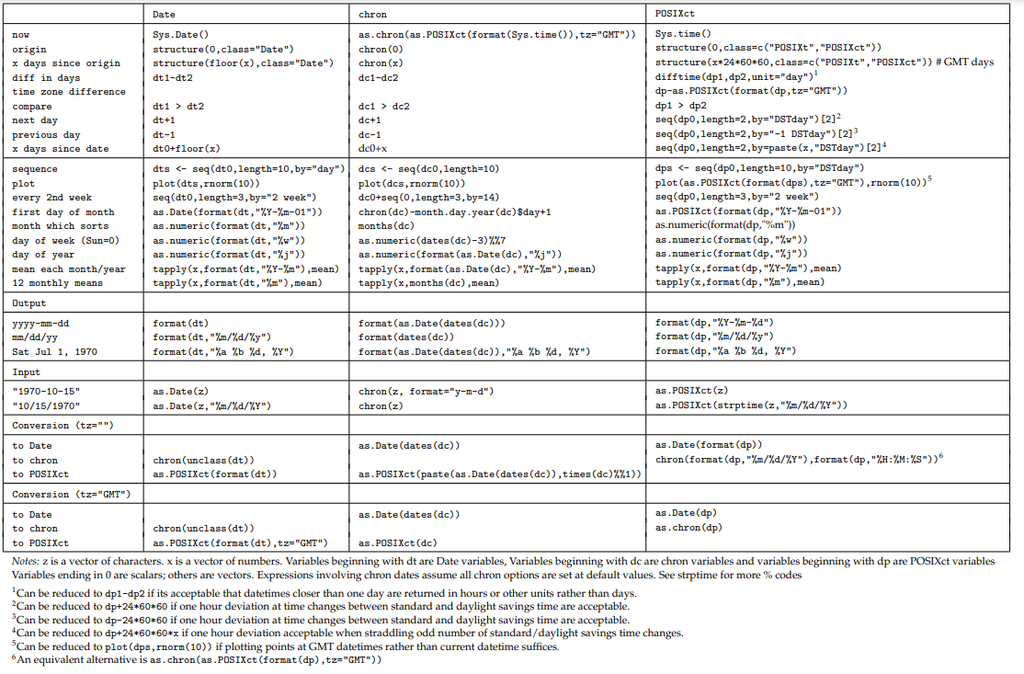

see page 31 and Table 1 (page 32) in 2004 Rnews article about conversion from one class to another

# Cautions

If you are doing calculations, know whether you are dealing with Dates or POSIX because the answers could be off by a factor of 86,400

TIMEZONES!!! - Time zones only affect how date is displayed. - Be careful with times around midnight if you are trying to truncate POSIX into a Date … the safest way is to convert them via an intermediary character variable. - Operations that combine date-times, like c(), will often drop the time zone. In that case, the date-times will display in your local time zone.

Know the default way dates are treated by your import functions! - `utils::read.csv()`

```r
str(read.csv('excel-origin-date.csv'))
```

```
## 'data.frame':    16 obs. of  4 variables:
##  $ numeric  : num  -1 0 0.25 0.5 0.75 ...
##  $ date     : chr  "###############################################################################################################"| __truncated__ "1/0/1900" "1/0/1900" "1/0/1900" ...
##  $ time     : chr  "###############################################################################################################"| __truncated__ "12:00:00 AM" "6:00:00 AM" "12:00:00 PM" ...
##  $ date.time: chr  "###############################################################################################################"| __truncated__ "01/00/1900 00:00:00" "01/00/1900 06:00:00" "01/00/1900 12:00:00" ...
```

- `readr::read_csv()`

```r
str(readr::read_csv('excel-origin-date.csv'))
```

```
## tibble [16 x 4] (S3: spec_tbl_df/tbl_df/tbl/data.frame)
##  $ numeric  : num [1:16] -1 0 0.25 0.5 0.75 ...
##  $ date     : chr [1:16] "###############################################################################################################"| __truncated__ "1/0/1900" "1/0/1900" "1/0/1900" ...
##  $ time     : chr [1:16] "###############################################################################################################"| __truncated__ "12:00:00 AM" "6:00:00 AM" "12:00:00 PM" ...
##  $ date-time: chr [1:16] "###############################################################################################################"| __truncated__ "01/00/1900 00:00:00" "01/00/1900 06:00:00" "01/00/1900 12:00:00" ...
##  - attr(*, "spec")=
##   .. cols(
##   ..   numeric = col_double(),
##   ..   date = col_character(),
##   ..   time = col_character(),
##   ..   `date-time` = col_character()
##   .. )
```

- `readxl::read_excel()`

```r
str(readxl::read_excel('excel-origin-date.xlsx'))
```

```
## tibble [10 x 4] (S3: tbl_df/tbl/data.frame)
##  $ numeric  : num [1:10] -1 0 0.25 0.5 0.75 ...
##  $ date     : POSIXct[1:10], format: "1899-12-30 00:00:00" "1899-12-31 00:00:00" ...
##  $ time     : POSIXct[1:10], format: "1899-12-30 00:00:00" "1899-12-31 00:00:00" ...
##  $ date-time: POSIXct[1:10], format: "1899-12-30 00:00:00" "1899-12-31 00:00:00" ...
```

- `openxlsx::read.xlsx()`

```r
str(openxlsx::read.xlsx('excel-origin-date.xlsx'))
```

```
## 'data.frame':    9 obs. of  4 variables:
##  $ numeric  : num  -1 0 0.25 0.5 0.75 ...
##  $ date     : num  -1 0 0.25 0.5 0.75 ...
##  $ time     : num  -1 0 0.25 0.5 0.75 ...
##  $ date-time: num  -1 0 0.25 0.5 0.75 ...
```

- `tidyxl::xlsx_cells()`

```r
str(tidyxl::xlsx_cells('excel-origin-date.xlsx')[,1:11])
```

```
## tibble [46 x 11] (S3: tbl_df/tbl/data.frame)
##  $ sheet    : chr [1:46] "Sheet1" "Sheet1" "Sheet1" "Sheet1" ...
##  $ address  : chr [1:46] "A1" "B1" "C1" "D1" ...
##  $ row      : int [1:46] 1 1 1 1 2 2 2 2 3 3 ...
##  $ col      : int [1:46] 1 2 3 4 1 2 3 4 1 2 ...
##  $ is_blank : logi [1:46] FALSE FALSE FALSE FALSE FALSE FALSE ...
##  $ data_type: chr [1:46] "character" "character" "character" "character" ...
##  $ error    : chr [1:46] NA NA NA NA ...
##  $ logical  : logi [1:46] NA NA NA NA NA NA ...
##  $ numeric  : num [1:46] NA NA NA NA -1 NA NA NA 0 NA ...
##  $ date     : POSIXct[1:46], format: NA NA ...
##  $ character: chr [1:46] "numeric" "date" "time" "date-time" ...
```

- From {`foreign`}
  - for Stata default is to import Stata Date format variables as Date class
- From {`haven` version 1.0.0}

> Support for date/times has substantially improved:
> - `read_dta()` now recognises “%d” and custom date types.
> - `read_sav()` now correctly recognises EDATE and JDATE formats as dates. Variables with format DATE, ADATE, EDATE, JDATE or SDATE are imported as Date variables instead of POSIXct.
> - `write_dta()` and `write_sav()` support writing date/times.
> - Support for `hms()` has been moved into the hms package. Time varibles now have class c(“hms”, “difftime”) and a units attribute with value “secs”.

# Resources

- General/Base R
  - https://cran.r-project.org/doc/Rnews/Rnews_2004-1.pdf
  - https://stats.idre.ucla.edu/r/faq/how-does-r-handle-date-values/
  - https://statistics.berkeley.edu/computing/r-dates-times
  - Chapter 6 in R for Dummies (“Going on a Date with R”)
- {`lubridate`}
  - https://blog.exploratory.io/5-most-practically-useful-operations-when-working-with-date-and-time-in-r-9f9eb8a17465
[^1]: See [the comments in this StackOverflow answer](https://stackoverflow.com/questions/43230470/how-to-convert-excel-date-format-to-proper-date-in-r) and [this R-bloggers post](https://www.r-bloggers.com/2013/08/date-formats-in-r/#:~:text=Date.,date%20is%20January%201%2C%201904.)